# Lab10

Spicy Bois

10/28/2019

# Lab 10

## Timeliness of the Answer as a Feature (Team)

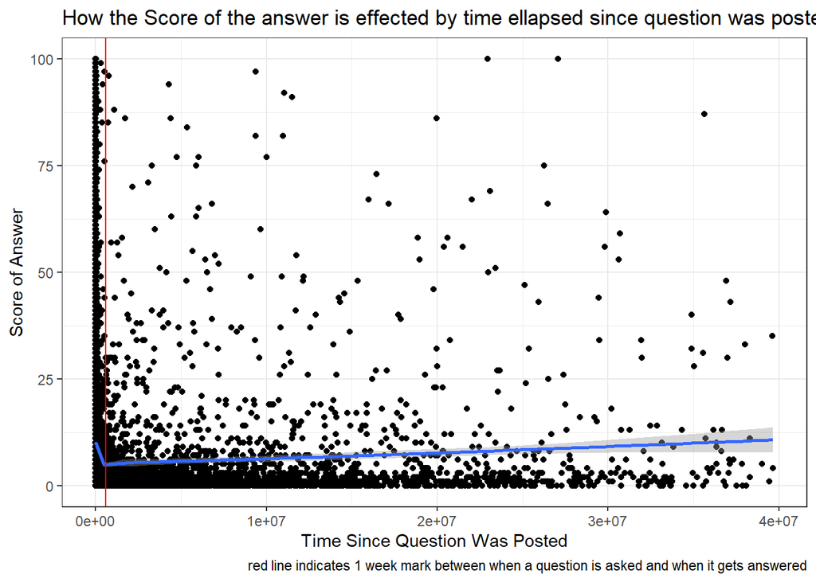

```r
merged <- answers %>%
  left_join(questions, c('ParentId' = 'Id'))

merged <- merged %>%
  mutate(total_time = CreationDate.x - CreationDate.y) %>%
  filter(total_time>0)


ggplot(data = merged, mapping = aes(y = Score.x, x = total_time)) +
  geom_point() +
  geom_smooth() +
  ylim(0, 100) +
  geom_vline(xintercept=604800, color = "red")+
  labs(x = "Time Since Question Was Posted", y = "Score of Answer", title = "How the Score of the answer is effected by time ellapsed since question was posted", caption = "red line indicates 1 week mark between when a question is asked and when it gets answered") +
  theme_bw()
```

**Findings:** As clearly shown in the graph, most questions are answered within the first week, and the sooner the answer, the more likely the answer will have a higher score. After this week mark, there is less correlation between answer score and time for the question to be answered, and the timeliness of the answer has less of an effect on the score itself.

**Conclusion:** Due to the size of the data set and the sheer number of outliers, we would not consider this data to be normally distributed. Since a z-score is a measurement of a value’s relationship to the mean (average) of a group of values, measured in terms of standard deviations from the mean, we would not be able to calculate z-scores and percentiles of an individual’s answer score due to the huge range of the data and the amount of outliers.

**What makes a good question or answer:** The ideal question is roughly 20-25 words long, and the ideal answer is roughly 100-500 words long, as keeping the questions/answers short are easier to read and comprehend, resulting in higher scores. Including code will also help raise user scores, so the best way to make a good question/answer is to keep it brief and concise, and include code if you can.

**Who could benefit from this:** As this is an analysis of score of answers/questions from Stack Overflow, this data could be helpful to people who frequent Stack Overflow, to help them ask better questions, and propose more concise answers. This could also be useful to the team working for Stack Overflow, to help promote better question asking and answer policies.

## Individual Sections

### Does the time of day effect the score? (Tyler)

[figure not shown]

```r
q_time <- questions %>%
  separate(CreationDate, into = c('Date', 'Time'), sep = " ") %>%
  separate('Time', into = c('hour', 'min', 'sec'), sep = ':') %>%
  mutate(temp = ifelse(hour>=16 & hour<=19 , "Good Time", "Bad Time")) %>%
  mutate(s = ifelse(Score>=51, "High Score", "Low Score")) %>%
  select(-X7)

a_time <- answers %>%
  separate(CreationDate, into = c('Date', 'Time'), sep = " ") %>%
  separate('Time', into = c('hour', 'min', 'sec'), sep = ':') %>%
  mutate(temp = ifelse(hour>=16 & hour<=19 , "Good Time", "Bad Time")) %>%
  mutate(s = ifelse(Score>=51, "High Score", "Low Score")) %>%
  select(-X7)

ggplot(data = a_time) +
  geom_bar(mapping  = aes(temp, fill = temp)) +
  facet_wrap(.~s) +
  theme_dark() +
  labs(title = "Time of Day Posting Relation to Scores for Questions", caption = "A high score is above 50 \n A Good Time is between 4pm and 8pm", x = "Time of Day", fill = "Time of Day", y = "Count")
```

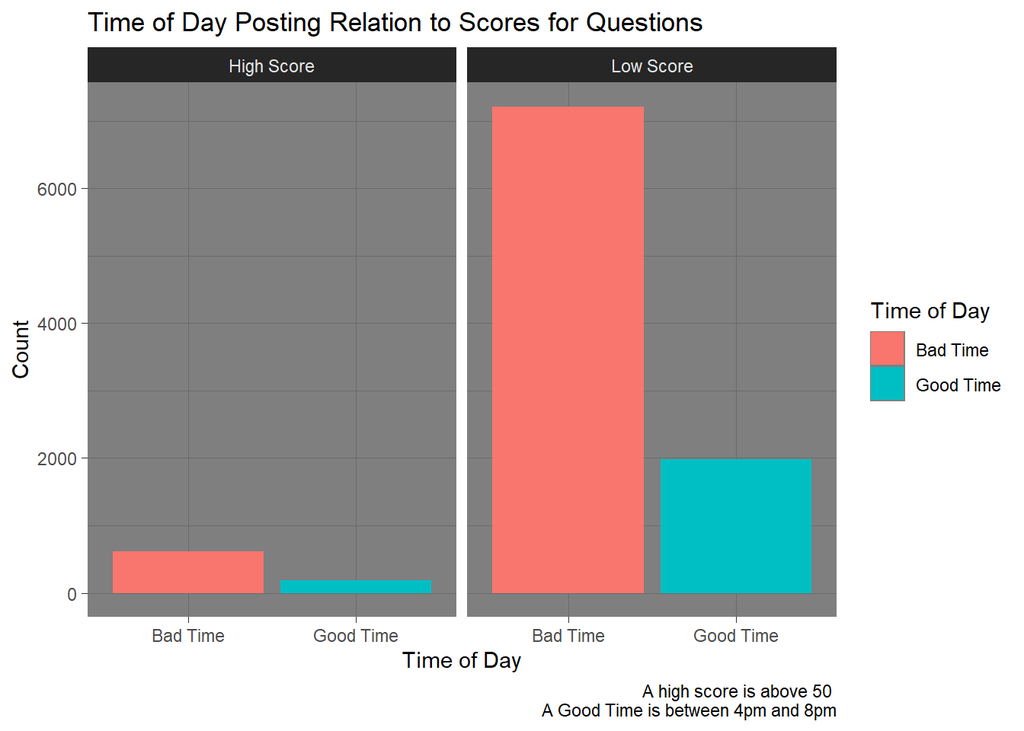

```r
ggplot(data = q_time) +
  geom_bar(mapping  = aes(temp, fill = temp)) +
  facet_wrap(.~s) +
  theme_dark() +
  labs(title = "Time of Day Posting Relation to Scores for Questions", caption = "A high score is above 50 \n A Good Time is between 4pm and 8pm", x = "Time of Day", fill = "Time of Day", y = "Count")
```

**Findings:** What I found is that the time of day doesn’t effect whether a post gets a high or a low score. This doesn’t change either for a question or an answer as most posts are low scoring posts, the time of day doesn’t effect the score significantly.

### Does code being included in questions/answers effect the user score? (Trent)

```r
q_code <- questions %>%
  mutate(code = str_detect(Body, "<code>")) %>%
  mutate(rank = case_when((Score>=50)~"high", ((Score<50)~"low"))) %>%
  mutate(rank.num = ifelse(Score>=50, 1, 0))

q_code_means <- q_code %>%
  group_by(code) %>% summarise(mean(rank.num))

q_code <- q_code %>% mutate(rank.fact = as.factor(rank.num))
levels(q_code$rank.fact) <- c('Low', 'High')

q_code_means
```

```
## # A tibble: 2 x 2
##   code  `mean(rank.num)`
##   <lgl>            <dbl>
## 1 FALSE           0.0712
## 2 TRUE            0.0914
```

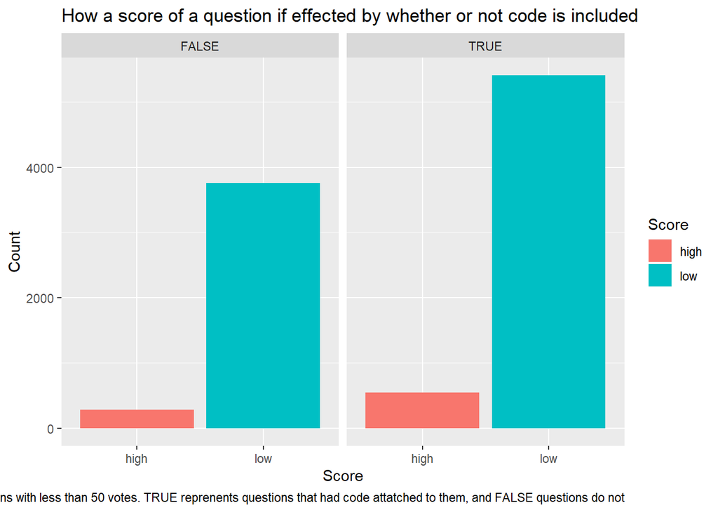

```r
ggplot(data = q_code) +
  geom_bar(mapping = aes(rank, fill = rank)) +
  facet_wrap(~ code) +
  facet_wrap(~ code) +
  labs(title = "How a score of a question if effected by whether or not code is included", x = "Score", y = "Count", fill="Score", caption = "high represents questions with scores over 50 votes, and low represents questions with less than 50 votes. TRUE reprenents questions that had code attatched to them, and FALSE questions do not")
```

```r
#answers code

a_code <- answers %>%
  mutate(code = str_detect(Body, "<code>")) %>%
  mutate(rank = case_when((Score>=50)~"high", ((Score<50)~"low"))) %>%
  mutate(rank.num = ifelse(Score>=50, 1, 0))

a_code_means <- a_code %>%
  group_by(code) %>% summarise(mean(rank.num))

a_code <- a_code %>% mutate(rank.fact = as.factor(rank.num))
levels(q_code$rank.fact) <- c('Low', 'High')

a_code_means
```

```
## # A tibble: 2 x 2
##   code  `mean(rank.num)`
##   <lgl>            <dbl>
## 1 FALSE          0.00771
## 2 TRUE           0.0603
```

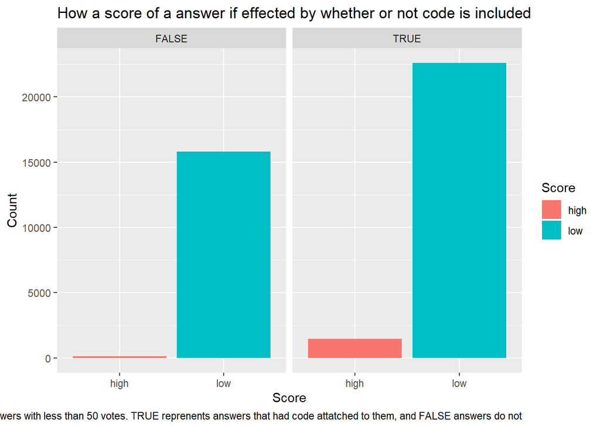

```r
ggplot(data = a_code) +
  geom_bar(mapping = aes(rank, fill = rank)) +
  facet_wrap(~ code) +
  labs(title = "How a score of a answer if effected by whether or not code is included", x = "Score", y = "Count", fill="Score", caption = "high represents answers with scores over 50 votes, and low represents answers with less than 50 votes. TRUE reprenents answers that had code attatched to them, and FALSE answers do not")
```

### Does the word count of the Answer effects the score? (Logan)

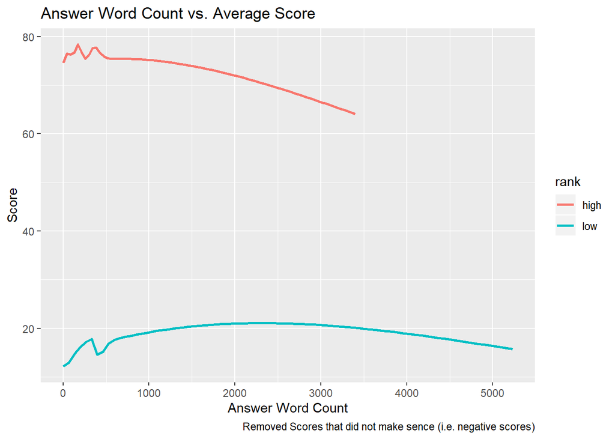

```r
answer <- read_csv("Answers_trunc.csv", skip = 1, col_names = c("Answer_Id", "Testee_Id", "Answered_Date", "Question_Id", "Score", "Answer", "X7"))
question <- read_csv("Questions_trunc.csv", skip = 1, col_names = c("Question_Id", "Creator_Id", "Creation_Date", "Total_Score", "Question", "Correct_Answer", "X7"))

data <-
  answer %>%
  left_join(question, "Question_Id") %>%
  mutate(Total_Time = Answered_Date - Creation_Date) %>%
  filter(Total_Time > 0) %>%
  select("Question_Id", "Answer_Id", "Creator_Id", "Testee_Id", "Creation_Date", "Answered_Date", "Total_Time", "Score", "Total_Score", "Question", "Answer", "Correct_Answer")

answer_count <- data %>%
  filter(Total_Score != 0, Total_Score >= Score, Score >= 0) %>%
  mutate(act_score = (100*Score/Total_Score), rank = case_when((act_score >= 50)~"high", ((act_score < 50)~"low")), count = str_count(Answer, "[:blank:]"))

ggplot(answer_count, aes(x = count, y = act_score, color = rank)) +
  geom_smooth(se = FALSE) +
  labs(title = "Answer Word Count vs. Average Score", x = "Answer Word Count", y = "Score", caption = "Removed Scores that did not make sence (i.e. negative scores)")
```

### Does the word count of the Question effect the score? (Logan)

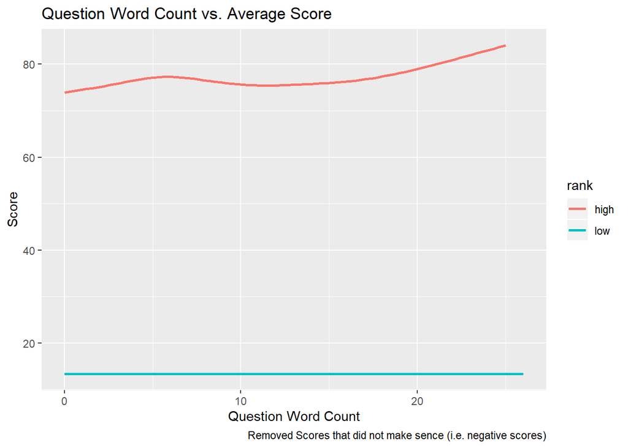

```r
question_count <- data %>%
  filter(Total_Score != 0, Total_Score >= Score, Score >= 0) %>%
  mutate(act_score = (100*Score/Total_Score), rank = case_when((act_score >= 50)~"high", ((act_score < 50)~"low")), count = str_count(Question, "[:blank:]"))

ggplot(question_count, aes(x = count, y = act_score, color = rank)) +
  geom_smooth(se = FALSE) +
  labs(title = "Question Word Count vs. Average Score", x = "Question Word Count", y = "Score", caption = "Removed Scores that did not make sence (i.e. negative scores)")
```

###Does the addition of additional questions or followup increase a question/answer’s score? (Joe)

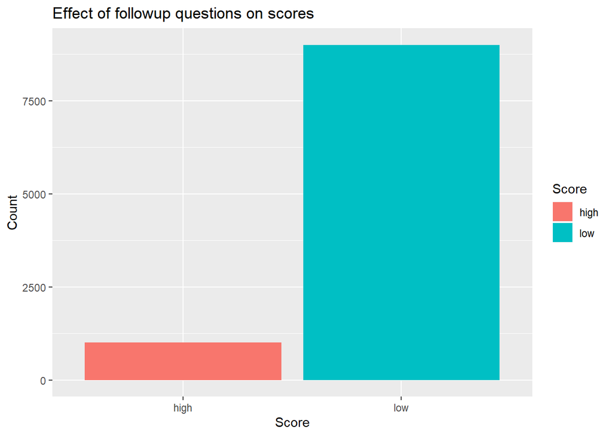

```r
questionmarks <- questions %>%
  select('Body', 'Score') %>%
  mutate(questions = str_detect(Body, "`?`")) %>%
  mutate(score = case_when((Score>=41)~"high", ((Score<41)~"low")))

ggplot(data = questionmarks) +
  geom_bar(mapping = aes(score, fill = score)) +
  labs(title = "Effect of followup questions on scores",
       x = "Score", y = "Count",
       fill="Score")
```

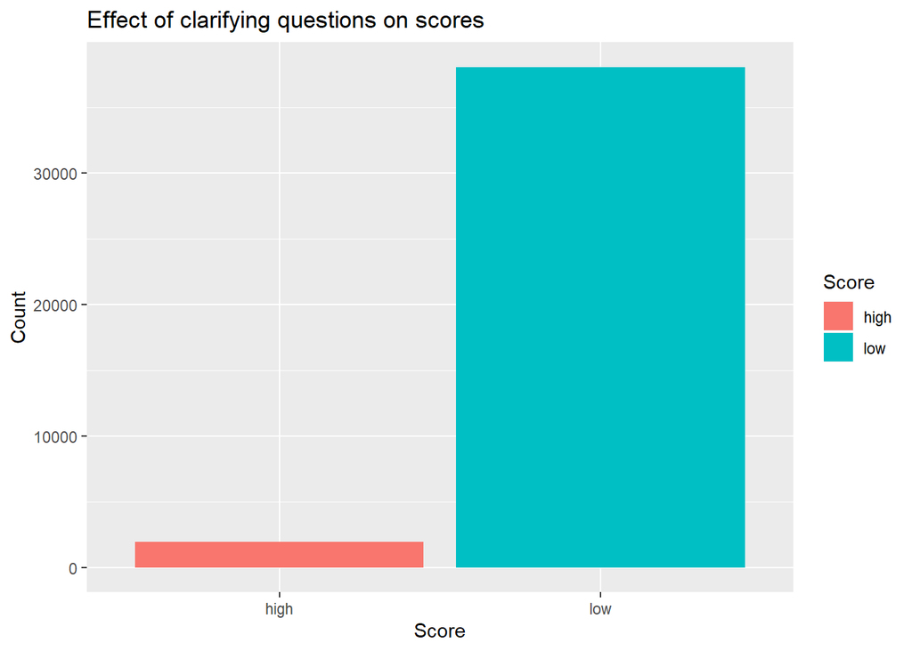

```r
clearup <- answers %>%
  select('Body', 'Score') %>%
  mutate(answers = str_detect(Body, "`?`")) %>%
  mutate(score = case_when((Score>=41)~"high", ((Score<41)~"low")))

ggplot(data = clearup) +
  geom_bar(mapping = aes(score, fill = score)) +
  labs(title = "Effect of clarifying questions on scores",
       x = "Score", y = "Count",
       fill="Score")
```

## Team Reports

**Tyler:** For this lab I analyzed how the time of day effected the amount of high or low scores. I did this by first separating the DateTime variable into a date and a time, and then separating the time into hour, min, and second. After separting that I set time to be the start and end of popular times people are online and a score to be the dictator of a high or low score. I then used ifelse’s to create new columns to for scores whether they were high or low and for times whether it was inside or outside the time frame.

**Logan:** I analyzed the effect that word length has on the score for both the question and answer. To do this I first split the graph into the high and low scores to differacite between the top scores and those who did not understandt the question. I then counted the number of words in the questoin. I did this by counting the number of spaces. Then I ploted what I found.